# Le Jeu du Taquin

# Introduction

## Le jeu du taquin

Le jeu du taquin est un puzzle qui a été créé vers 1870, depuis il a attiré l’intérêt de nombreux mathématiciens pour sa valeur en tant qu’un problème combinatoire.

Le jeu est composé de $n\cdot m-1$ petits carreaux numérotés à partir de $1$ qui glissent dans un cadre du format $n\times m$ laissant une case vide permettant de modifier la configuration des carreaux. Le jeu consiste à remettre dans l’ordre ces cases à partir d’une configuration initiale quelconque.

Le jeu est souvent connu dans les formats $3\times 3$ ou $4\times 4$, d’où l’appellation anglophone *8-puzzle* ou *15-puzzle* respectivement.

Le Rubik’s Cube est condéré comme l’un des descendants du taquin. (Wikipédia 2018)

## Complexité

Le jeu du taquin est le problème le plus grand de son type qui peut être résolu complètement (on peut trouver toutes les solution existent d’un problème donné). Il est simplement défini mais le problème est **NP-difficile**. (Reinefeld 1993)

Le problème est grand combinatoirement est exige une résolution guidée afin d’atteindre avant d’épuiser les résources (temps et mémoire).

L’espace d’état est de taille $\frac{(n\cdot m)!}{2}$ ce qui fait $181~440$ pour la variante $3\times3$.

En effet, il existe $(n\cdot m)!$ permutations des tuiles, une permutation sur deux est solvable, on peut évoquer l’argument de parité qui a été présenté dans (Johnson et Storey 1879) afin de montrer que la moitié des configurations initiales ne peuvent jamais pas atteindre l’état but en définissant une fonction invariante de mouvement des tuiles qui définit deux classes d’équivalence d’états *accessibles* et *non-accessibles*.

## Le but du projet

Le but du projet est de résoudre un problème réel à l’aide de la programmation logique. Notre choix s’est portée le jeu du taquin car il est intéressant en tant qu’un problème d’Intelligence Artificielle, et s’adapte bien à la programmation logique.

Dans ce projet on présentera ce problème mathématiquement et proposons des algorithmes de résolutions variées, une implémentation en **prolog** de ces algorithmes, et finalement une étude des résultats.

## Formulation du problème

Le problème est le mieux représenté par un graphe connexe. On défini l’espace d’état $E$ par toutes les configurations solvables du problème.

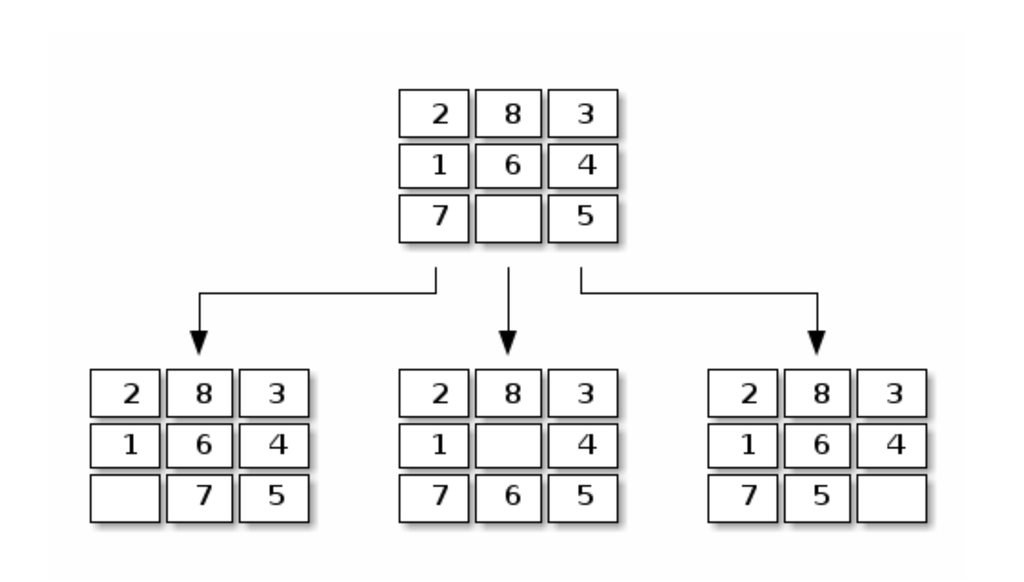

Une partie du graphe du taquin

On considère deux états adjacents si on peut passer de l’un vers l’autre en glissant une seule tuile voisine vers la case vide. La case vide a au moins 2 tuiles voisines (si elle est dans un coin), et au plus 4 (gauche, droite, haut, bas).

On cherche idéalement le chemin le plus court pour arriver au but à partir de l’état initiale, ce qui consiste un problème classique de recherche de chemins dans un graphe.

# Algorithmes

Ils existent de nombreux algorithmes pour la recherche d’un chemin dans un graphe, nous avons implémenté quelques algorithmes qui correspondent bien à notre problème et qui s’adaptent bien aux principes de la programmation logique.

## Depth-First Search (DFS)

L’algorithme de parcours en profondeur (DFS) est un algorithme complet permettant de trouver un chemin dans un graphe.

Cette algorithme est le principe *inné* de **prolog** de l’arbre de résolution.

L’implémentation de DFS dans un arbre se fait simplement par le code

```
dfs(Etat, [Etat]) :- final(Etat).
dfs(E1, [E1|Chemin]) :-
    adjacent(E1, E2),
    dfs(E2, Chemin).
```

On obtient notre chemin par la requête

```
?- dfs([EtatInitial], Chemin).
```

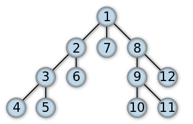

L’ordre de parcours des nœuds dans l’algorithme DFS

Néanmoins, cet algorithme ne fonctionne pas pour la plupart des puzzles; il parcourt en profondeur donc il prendra toujours le premier adjacent de `E1` jusqu’à ce que le dernier `E1` n’a plus d’adjacents, et puis tentera le deuxième adjcent du `E1` précedant, et ainsi suite…sauf que dans le jeu du taquin *il y a toujours au moins 2 adjacents!* le programme est donc infiniment récursif.

Si on suppose que le prédicat `adjacent/2` est défini par

```
adjacent(A, B) :- adjacent(A, B, gauche).
adjacent(A, B) :- adjacent(A, B, droite).
adjacent(A, B) :- adjacent(A, B, haut).
adjacent(A, B) :- adjacent(A, B, bas).
```

L’arbre de résolution de prolog dépend de l’ordre de définition des prédicats, il tentera les adjacents dans l’ordre (gauche, droite, haut, bas) donc pour l’état suivant qui est adjacent au but, il modulera entre ces deux états jusqu’à ce qu’il na plus de mémoire.

```
1 2 3       1 2 3       1 2 3       1 2 3       1 2 3
4 5         4 5         4   5       4 5         4   5
7 8 6       7 8 6       7 8 6       7 8 6       7 8 6       ...
```

Il est donc nécessaire d’interdire de prendre un adjacent `E2` déjà visité. Or, un nouveau problème s’introduit:

```
1 2 3       1 2 3       1 2 3       1 2 3       1 2 3
4 5         4 5           4 5       7 4 5       7 4 5
7 8 6       7 8 6       7 8 6         8 6       8   6       ...
```

Nous avons testé cet algorithme avec cette configuration, il fait 27 mouvements afin d’arriver au but ! Théoriquement, il trouvera toujours un chemin, mais en pratique pour la plupart des configurations le overflow arrive avant de trouver une solution.

D’où la nécessité de prendre des décisions informées, nous allons ainsi introduire la notion d’**heuristique**.

## Heuristiques

Une **fonction heuristique** sur un graphe est une fonction $h:E\rightarrow\mathbb{N}$ où $E$ est l’espace d’états du problème, $h(n)$ représente le coût estimé pour arriver au but à partir du nœud $n$, on appelle *coût* d’un chemin la longueur d’un chemin.

On appelle **heuristique admissible** une heuristique $h$ telle que
$$\forall n\in E, h(n) \leq h^*(n)$$
où $h^*(n)$ est le vrai coût minimal pour arriver au but à partir du nœud $n$ (dite l’*heuristique parfaite*).

Trivialement, l’heuristique nulle est admissible mais elle ne rajoute aucune valeur à la résolution du graphe.

(Wikipedia contributors 2018)

Nous allons introduire deux heuristiques qu’on a utilisé dans nos algorithmes.

### Distance de Hamming

La distance de Hamming est définie pour deux listes (ou mots) de même taille par le nombre de valeurs qui diffèrent entre ces deux listes.

Soit mathématiquement, avec $A$ l’ensemble des atoms (ou alphabet)
$$\begin{align*}
d_{\text{Hamming}}: A^n \times A^n &\rightarrow \mathbb{N}\\
(x, y) &\mapsto \sum_{i=1}^n (1-\delta_{x[i],y[i]}) =
\begin{cases}
0 &\text{si } x[i] = y[i]\\
1 &\text{sinon}
\end{cases}
\end{align*}$$

Dans notre contexte, on ne prend pas en compte de la case vide dans ce calcul.

L’heuristique de Hamming est donc la distance de Hamming entre le tableau du nœud $n$ et le nœud final. Cette heuristique est admissible.

### Distance de Manhattan

La distance de Manhattan est la distance $L_1$ dans les espaces de Banach. Soit $V$ un espace de Banach de dimension $n$.
$$\begin{align*}
d_1: V \times V &\rightarrow \mathbb{R}_+\\
(x, y) &\mapsto \sum_{i=1}^{\dim V} |x_i - y_i|
\end{align*}$$

Dans notre contexte, la distance $d_1$ est définie sur $V=\{1,\ldots,n\}\times\{1,\ldots,m\}$, soit $I=\{1,\ldots,nm-1\}$, on définit la fonction de position d’une tuile dans un état $e\in E$
$$\begin{align*}
\textrm{pos}_e: I &\rightarrow V\\
p &\mapsto (i, j)
\end{align*}$$
La distance de Manhattan entre deux états se donne donc par
$$\begin{align*}
d_{\text{Manhattan}}: E \times E &\rightarrow \mathbb{N}\\
(u, v) &\mapsto \sum_{p\in I} d_1\left(\textrm{pos}_u(p), \textrm{pos}_v(p)\right)
\end{align*}$$

De même, l’heuristique de Manhattan est la distance entre le nœud $n$ et le nœud final et ne prend pas compte de la case vide. Cette heuristique est admissible.

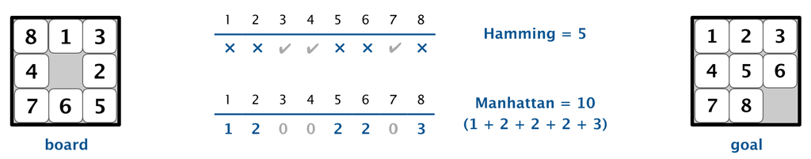

## Algorithme Greedy

Dans le cas du jeu du taquin, l’algorithme de Greedy est un algorithme d’optimisation locale; lorsqu’il faut faire un choix parmi une liste d’adjacents il prend l’adjacent qui minimise la fonction coût.

L’algorithme n’est pas toujours optimale, dans notre implémentation nous avons obtenue les meilleurs résultats pour l’heuristique définie par

$$h(n) := \textrm{Manhattan}(n) + 3\cdot\textrm{Hamming}(n)$$

Cette heuristique n’est pas admissible car elle vaut pour un état $n$ adjacent au but
$$h(n) = (1) + 3(1) = 4 > 1 = h^*(n)$$
mais l’admissiblité n’est pas importante pour cet algorithme.

L’algorithme trouve une solution en quelques secondes pour toutes les configurations du taquin de taille $3\times3$, la plupart de ses solutions ne sont pas optimales.

Pour les tailles plus grandes, l’algorithme prends plus de temps et ne trouve pas toujours une solution car ses choix locaux sont définitifs (il n’y a pas d’alternatif dans le backtracking).

## Iterative Deepening DFS (ID-DFS)

L’algorithme ID-DFS est une variante du DFS, il effectue une recherche en profondeur DFS itérativement pour un profondeur maximal donnée $d$, et l’incrémente succéssivement en commençant par $d=0$ jusqu’à ce qu’il trouve une solution. (Wikipedia contributors 2019b)

Classiquement, $d=0$ à la première itération mais cela est loin d’être optimale, nous proposons donc de commencer par une sous-estimation du longeur du chemin, $d=h(n_\text{initial})$ est une sous-estimation si $h$ est une heuristique admissible.

### Compléxité

- Compléxité en temps: $O(b^d)$
- Compléxité spaciale: $O(d)$

où $d$ est le profondeur, et $b$ est le facteur de branchement.

Ceci est dû au fait qu’une fois $d$ est grand, ID-DFS est presque comme DFS et a les mêmes problèmes.

## Algorithme A*

L’algorithme A* est complet, optimal et efficace. C’est un algorithme *à mémoire*, qui a une compléxité spaciale importante.

A* utilise la fonction d’évaluation $f$ défini par
$$f(n) = g(n) + h(n)$$
où

- $f(n)$ le coût total estimé au nœud $n$
- $g(n)$ le vrai coût pour arriver au nœud $n$ à partir du nœud initial
- $h(n)$ le coût estimé pour arriver au but à partir du nœud $n$

Il garde une liste des candidats, et en choisit succéssivement celui qui minimise le coût $f$ et rajoute tous ses états adjacents (non visité) à la liste des candidats.

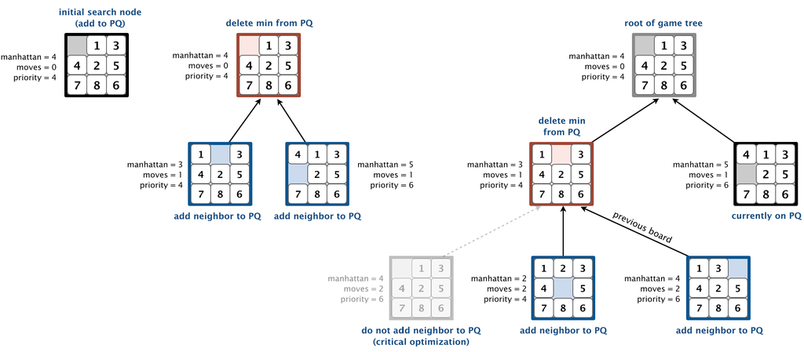

Les solutions obtenues sont optimale si l’heuristique est admissible, les meilleurs résultats sont obtenus pour la distance de Manhattan. (Wikipedia contributors 2019a)

Pour les configurations faciles les solutions sont obtenues instantanément, mais pour les configurations difficiles l’algorithme peut prendre plus de temps que les algorithmes précédents. Néanmoins, pour les tailles plus grande que $3\times3$, A* est le meilleur algorithme pour trouver une solution.

# Implémentation

## Modèle du programme

Nous avons implémenté notre programme sous l’enivronement [SWI Prolog](https://www.swi-prolog.org/) qui est complet, libre, bien documenté, et permet de construire des programmes modulaires.

Notre programme donc est modulaire et réutilisable.

```
taquin
├── util
│   ├── core.pl....................modèle principale du jeu
│   ├── hamming.pl.................définition de l'heuristique hamming
│   ├── heuristic.pl...............wrapper pour les heuristiques
│   ├── manhattan.pl...............définition de l'heuristique manhattan
│   ├── moves.pl...................définition des adjacents
│   └── test.pl....................outils pour tester le programme
├── taquin_astar.pl................algorithme A*
├── taquin_dfs.pl..................algorithme du type DFS
├── taquin.pl......................wrapper principal
├── test_3x3.pl....................exemples de puzzles 3×3
├── test_3x4.pl....................exemples de puzzles 3×4
├── test_4x4.pl....................exemples de puzzles 4×4
└── README.md......................petit guide d'utilisation
```

Nous avons implémenté le jeu taquin $n\times m$ à l’aide du prédicat `dim/2` qui prend en argument le nombre de lignes et le nombre des colonnes. La base de connaissance doit contenir une et seulement une dimension.

Nous fournissons dans le module `util/core` le prédicat `goal/1` qui définit l’état objectif pour la dimension prédéfinie dans la base de connaissance. Le module `core` dépend des modules `util/moves` et `util/heuristic`.

Le module `util/moves` définit l’adjacence à l’aide du prédicat `move/3`

```
move(Before, After, Direction)
```

qui est vrai si en glissant une tuile de l’état `Before` dans la direction `Direction` l’état `After` est obtenu.

Le module `util/heuristic` fournit le prédicat `h/2` qui calcule la fonction heuristique d’un état donné, la fonction heuristique à utiliser doit être définie dans la base de connaissance à l’aide du prédicat `heuristic/1` qui prend l’une des valeurs `manhattan`, `hamming` et `m3h`. Ce module dépend des modules `util/manhattan` et `util/hamming`.

Le module `taquin_dfs` fournit les prédicats des algorithmes basés sur le principe DFS, et le module `taquin_astar` fournit le prédicat de l’algorithme A*. Ces modules dépendent du module `util/core` (qui inclut les modules nécessaires).

Le module `taquin` fournit un *wrapper* pour tous les algorithmes implémentés dans les prédicats `solve/3` et `solve/4`.

Utilisation:

```
solve(+Puzzle, -Solution, +Algorithm, +Heuristic).
```

- `+Puzzle`: une configuration initiale donnée
- `-Solution`: un chemin (liste des états) du but jusqu’à `Puzzle`
- `+Algorithm`: l’algorithme à utiliser (`dfs`, `iddfs`, `greedy` ou `astar`)
- `+Heuristic`: heuristique à utiliser (`manhattan`, `hamming` ou `m3h`)

Le prédicat `solve/3` choisit lui-même l’heuristique en fonction de l’algorithme choisi (recommandé).

## Algorithmes

### Depth-First Search

La définition du prédicat `dfs` est similaire à celle présentée dans l’explication de l’agorithme en y rajoutant la contrainte `\+member(E, Chemin)` afin d’éviter les problèmes dont nous avons parlé.

```
% dfs(Etat, CheminEnCours, CheminFinal)
dfs(Initial, Path, Path) :- goal(Initial).      % condition d'arrêt
dfs(Initial, Visited, Path) :-
    move(Initial, State, _),                    % un mouvement possible
    \+member(State, Visited),                   % l'état n'existe pas dans le chemin
    dfs(State, [State|Visited], Path).          % reste du chemin

% dfs/2: wrapper pour dfs/3 avec chemin vide
dfs(Initial, Path) :- dfs(Initial, [], Path).
```

### Iterative Deepening DFS

La définition d’une itération de ID-DFS est similaire à celle de DFS, en y rajoutant la contrainte de profondeur.

```
% iddfs(Etat, CheminEnCours, CheminFinal, Profondeur)
iddfs(Initial, Path, Path, _) :- goal(Initial). % condition d'arrêt
iddfs(Initial, Visited, Path, Depth) :-
    Depth > 0,                                  % profondeur non nul
    move(Initial, State, _),                    % un mouvement possible
    \+member(State, Visited),                   % l'état n'existe pas dans le chemin
    D1 is Depth - 1,                            % décrementer le profondeur
    iddfs(State, [State|Visited], Path, D1).    % reste du chemin
```

Il reste d’initialiser la boucle avec un profondeur maximal sous-estimé par une heuristique admissible

```
% iddfs/2 initialise la boucle avec prondeur max = h(état initial)
iddfs(Initial, Path) :- h(Initial, H), iddfs(Initial, Path, H), !.

% iddfs/3 wrapper d'une itération de iddfs de profondeur donné
iddfs(Initial, Path, Depth) :- iddfs(Initial, [], Path, Depth).
iddfs(Initial, Path, H) :- H1 is H + 1, iddfs(Initial, Path, H1).
```

### Algorithme Greedy

La définition de l’algorithme Greedy est similaire à celui de DFS, en prenant le meilleur mouvement (localement) non visité.

```
% greedy(Etat, CheminEnCours, CheminFinal)
greedy(Initial, Path, Path) :- goal(Initial).   % condition d'arrêt
greedy(Initial, Visited, Path) :-
    bestMove(Initial, Visited, State),          % le meilleur mouvement
    gredy(State, [State|Visited], Path).        % reste du chemin

% greedy/2: wrapper pour greedy/3 avec chemin vide
greedy(Initial, Path) :- greedy(Initial, [], Path).
```

Le prédicat `greedy/3` se définit grace aux prédicats auxiliaires

```
% cheapest/2 trouve l'état avec l'heuristique la plus petite
cheapest([State], State).
cheapest([A, B|T], M) :- h(A, Ac), h(B, Bc), Ac =< Bc, cheapest([A|T], M).
cheapest([A, B|T], M) :- h(A, Ac), h(B, Bc), Ac > Bc, cheapest([B|T], M).

% bestMove/3 trouve le voisin non-visité le moins cher
bestMove(State, Visited, Next) :-
    % construire la liste des voisins non-visités
    findall(
        Neighbor,
        (move(State, Neighbor, _), \+member(Neighbor, Visited)),
        Neighbors
    ),
    % en choisir le voisin qui minimise l'heuristique
    cheapest(Neighbors, Next).
```

On voit que contairement à `dfs/3` qui contient la clause `move(Initial, State, _)` permettant d’obtenir `State` dans toutes les directions possibles, `greedy/3` contient la clause `bestMove(Initial, Visited, State)` qui choisit toujours le même `State` même si le chemin ne mène pas au but, l’algorithme peut donc simplement échouer s’il se trouve dans un état sans nouveaux voisins.

### Algorithme A*

L’algorithme A* est le plus complexe parmi les algorithmes présentés, contrairement aux autres algorithmes, il garde une liste des candidats qui ne cesse d’augmenter jusqu’à ce qu’un chemin est trouvé.

Les algorithmes de type DFS gardent également une liste de candidats implicite: **une pile**, c’est-à-dire une liste LIFO (last in first out). En revanche, avec l’algorithme A* il faut gérer la liste des candidats explicitement, afin d’optimiser le temps de calcul nous utilisons un **Priority Queue** (file de priorité), qui est une liste d’éléments ordonnés dans l’ordre (croissant ou décroissant) par rapport à une fonction de priorité.

Notre fonction de priorité est $f(n)=g(n)+h(n)$ que nous souhaitons minimiser, notre Priority Queue est donc dans l’ordre croissant par rapport à $f$.

Tout d’abord, nous définissons le terme `node/3` qui représente un nœud du graphe de résolution de A*. Le terme `node(S, P, F)` se définit par:

- **Etat `S`:** un configuration du puzzle.
- **Chemin `P`:** le chemin pour arriver à `S`.
- **Coût `F`:** la fonction $f$ évaluée en `S` par rapport au chemin `P`.

Au lieu d’avoir à trier la liste, nous avons implémenté les prédicats `pushQueue/3` et `appendQueue/3` qui permettent d’insérer des éléments dans le Queue dans le bon placement directement.

```
% pushQueue(+Node, +Queue, -NewQueue)
% permet de rajouter un nœud au Queue
pushQueue(Node, [], [Node]) :- !. % queue null
pushQueue(node(S1,P1,F1), [node(S2,P2,F2)|Q], [node(S1,P1,F1),node(S2,P2,F2)|Q]) :-
    F1 =< F2,   % le nouveau nœud est le moins cher
    !.          % arrêter la recherche
pushQueue(node(S1,P1,F1), [node(S2,P2,F2)|Q0], [node(S2,P2,F2)|Q]) :-
    pushQueue(node(S1,P1,F1), Q0, Q).

% appendQueue(NodeList, Queue, NewQueue)
% permet de rajouter une liste de nœuds non-ordonnés au Queue
appendQueue([], Q, Q).          % liste nulle
appendQueue([Node|T], Q0, Q) :-
    pushQueue(Node, Q0, Q1),    % rajouter le premier
    appendQueue(T, Q1, Q).      % rajouter le reste
```

Chaque itération de A* consiste à générer les enfants du nœud prioritaire et de les rajouter au Queue.

```
% astar_search(NodeQueue, Path, Solution)
astar_search([node(Goal, Path, _)|_], _, Path) :- goal(Goal).
astar_search([node(S, P, H)|Queue], Visited, Solution) :-
    % générer les voisins de S
    findall(Neighbor, move(S, Neighbor, _), Sneighbors),
    % générer une liste des enfants
    nodeChildren(node(S, P, H), Sneighbors, Visited, Children),
    % rajouter les enfants au Queue
    appendQueue(Children, Queue, SortedQueue),
    % recommencer l'itération avec le nouveau Queue
    astar_search(SortedQueue, [S|Visited], Solution).
```

Le prédicat `nodeChildren/4` permet de générer les enfants d’un nœud à partir de la liste de ses voisins.

```
% nodeChildren(ParentNode, CandidateChildren, Visited, Children)
nodeChildren(_, [], _, []) :- !. % pas de candidats
nodeChildren(node(Parent, Path, ParentF), [Child|Others], Visited,
        [node(Child, [Child|Path], F)|Children]) :-
    % l'état n'existe pas dans le chemin
    \+member(Child, Visited),
    % calculer le coût de l'enfant
    length(Path, G1), h(Child, H), F is G1 + 1 + H,
    % générer les enfants pour le reste des voisins
    nodeChildren(node(Parent, Path, ParentF), Others, [Child|Visited], Children),
    !. % ignorer la règle suivante et passer aux autres candidats
nodeChildren(Node, [_|Others], Visited, Children) :-    % l'état existe dans le chemin
    nodeChildren(Node, Others, Visited, Children).      % passer aux autres candidats
```

Il ne reste que de lancer l’algorithme avec le queue contenant l’état initial dont le coût est $f(n_0)=h(n_0)$.

```
astar(Initial, Path) :-
    h(Initial, H),                                          % évaluer f(n) = h(n)
    astar_search([node(Initial, [], H)], [Initial], Path).  % lancer A*
```

## Utilisation du programme

Nous avons fourni le module `util/test` qui permet de tester le programme, le module définit les prédicats

- `printState/1`: affiche un état comme une grille
- `printSolution/2`: affiche un chemin
- `testPuzzle/3, testPuzzle/2, testPuzzle/1`: wrapper pour résoudre et afficher la solution (les 2<sup>ème</sup> et 3<sup>ème</sup> arguments sont optionnels)
- `debugPuzzle/3`: affiche le temps de résolution et longueur du chemin

Nous fournissons quelques exemples de puzzles dans les fichiers `test_3x3.pl`, `test_3x4.pl` et `test_4x4.pl`, à l’aide de term `puzzle(Puzzle, Difficulty)`.

Pour utiliser notre programme, lancer l’un de nos programmes tests

```bash
$ swipl test_3x3.pl
```

et lancer la requête suivante:

```
% Algorithm = dfs, iddfs, greedy ou astar
% Heuristic = manhattan, hamming ou m3h
?- puzzle(Puzzle, Difficulty),
   Algorithm = astar, Heuristic = manhattan,
   testPuzzle(Puzzle, Algorithm, Heuristic).
```

## Quelques résultats

Nous avons testé nos algorithmes sur quelques exemples représentatifs, voici les résultats trouvés pour les puzzles de taille $3\times3$.

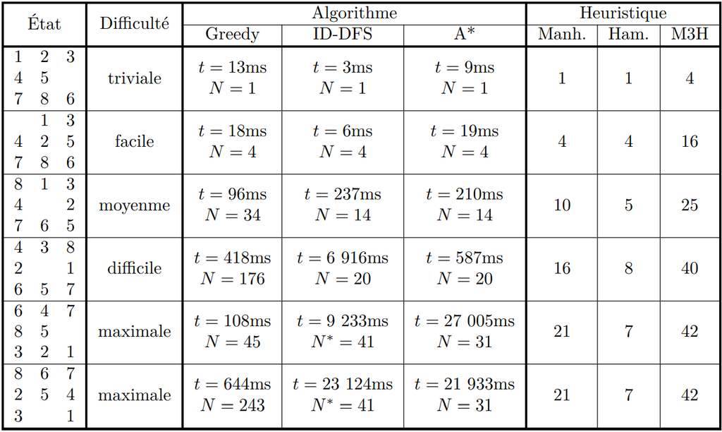

Les états classés de difficulté *maximale* sont les configurations avec les chemins les plus longue pour un puzzle 3×3. (Reinefeld 1993)

Les résultats du DFS sont absents du tableau car pour tous états non triviaux l’algorithme ne trouve pas un chemin avant qu’on perde notre patience.

Les solutions de Greedy sont calculé avec l’heuristique local `m3h`. Les solutions de ID-DFS et A* sont trouvé avec l’heuristique de Manhattan à part ceux marquées avec un asterisk; elles sont trouvées avec `m3h` qui n’est pas admissible, car l’algorithme met beaucoup de temps pour trouver le chemin avec Manhattan et nous n’avons jamais réussi à obtenir un résultat. Néanmoins, si on part directement de l’itération de profondeur 31, les chemins optimaux sont trouvé en $237~514 \text{ms}\approx 4\text{min}$ et $271~363\text{ms}\approx 4.5\text{min}$ respectivement.

# Conclusion

## Analyse des résultats

Nous avons trouvé conformément à nos attentes que l’algorithme A* est le mieux adapté à ce problème. Les autres algorithmes peuvent être plus rapides et/ou chanceux dans les cas simples, mais dans les cas les plus complexes et surtout en dimensions plus grandes, A* est le plus efficace et le meilleur candidat pour trouver une solution en temps raisonnable.

Néanmoins, l’optimisation locale de Greedy le rend un candidat respectable pour trouver un chemin rapidement, ce que nous avons présenté pendant notre soutenance. En effet, pour l’une des configurations 3×4 que nous avons testé Greedy était le seul à nous donner une réponse (en temps raisonnable).

## Développements possibles du projet

### Algorithme IDA*

Malgré la lenteur de l’algorithme ID-DFS, son idée reste très intéressante. Sa variante **Iterative Deepening A* (IDA*)**(Korf 1985) emprunte la fonction coût de A* $f(n)=g(n)+h(n)$ et donne des solutions plus rapidement que A* et en économisant beaucoup de mémoire par rapport à ce dernier. Il sera certainement plus intéressant d’étudier et d’implémenter l’algorithme IDA*.

### Mouvements

Nous avons implémentés une grille de taille dynamique, ce qui rend le projet plus intéressant. Néanmoins, chaque appelle au prédicat `move/3` nécessite un calcul non-négligeable dans les cas complexes, il est ainsi important de définir les mouvements *à la main* pour les tailles 3×3 et 4×4.

### Portabilité

Les algorithmes utilisés dans ce projet peuvent s’appliquer à la résolutions de différents problèmes (e.g. Rubik’s Cube, Flowshop, etc). Il sera certainement intéressant d’adapter l’implémentation afin d’avoir un code compatibles avec plusieurs instances de problèmes de graphe.

## Apport personnel

Ce projet a été une excellente opportunité pour approfondir notre connaissance en IA et notre maîtrise de la programmation logique.

# Références

Johnson, W. W., et W. E. Storey. 1879. « Notes on the 15-Puzzle ». https://www.jstor.org/stable/2369492.

Korf, Richard. 1985. « Depth-First Iterative-Deepening: An Optimal Admissible Tree Search ». https://cse.sc.edu/~mgv/csce580f09/gradPres/korf_IDAStar_1985.pdf.

Reinefeld, Alexander. 1993. « Complete Solution of the Eight-Puzzle and the Benefit of Node Ordering in IDA * ». https://www.ijcai.org/Proceedings/93-1/Papers/035.pdf.

Wikipédia. 2018. « Taquin — Wikipédia, l’encyclopédie libre ». http://fr.wikipedia.org/w/index.php?title=Taquin&oldid=153121375.

Wikipedia contributors. 2018. « Admissible heuristic — Wikipedia, The Free Encyclopedia ». https://en.wikipedia.org/w/index.php?title=Admissible_heuristic&oldid=873230067.

———. 2019a. « A* search algorithm — Wikipedia, The Free Encyclopedia ». https://en.wikipedia.org/w/index.php?title=A*_search_algorithm&oldid=925009518.

———. 2019b. « Iterative deepening depth-first search — Wikipedia, The Free Encyclopedia ». https://en.wikipedia.org/w/index.php?title=Iterative_deepening_depth-first_search&oldid=925129768.